# Data Tidying Project

Francisko de Moraes Rezende

2019/01/15

### Get Data

The following chunk has code for obtaining data from two data sets:

[Data Set 1](https://data.world/retail/department-store-sales): Sales from the Retail Trade and Food Services Report from the US Census. This data set only covers Department Stores, though the report covers a wide range of retail types. [1992-2016]

```r
#1992-2016
#https://data.world/retail/department-store-sales

GET("https://query.data.world/s/gdk7iwtlisq6vkktmybqqr7hjjty5s", write_disk(tf <- tempfile(fileext = ".xls")))
```

```
## Response [https://download.data.world/file_download/retail/department-store-sales/retail-trade-report-department-stores.xls?auth=eyJhbGciOiJIUzUxMiJ9.eyJzdWIiOiJwcm9kLXVzZXItY2xpZW50OnNoYW5lbGxpcyIsImlzcyI6ImFn….jBFlyy1aloE-EpeYyosD3iRaDPoY75DBqdh7suLoZxKcrsG8N5GtOiFb6sNMjTqqclsHX7P8RUw7T5sAArPbc…
##   Date: 2019-01-15 18:56
##   Status: 200
##   Content-Type: application/vnd.ms-excel
##   Size: 62.5 kB
## <ON DISK>  /tmp/RtmpKCTxCK/file31d64b2312c.xls
```

```r
df1 <- read_excel(tf)

#2009-2014
# https://data.world/garyhoov/retail-sales-growth
GET("https://query.data.world/s/py7kinxvyuxjpzwdjs2ti4wdmui6bi", write_disk(tf <- tempfile(fileext = ".xls")))
```

```
## Response [https://download.data.world/file_download/garyhoov/retail-sales-growth/US%20Retail%20Sales%20by%20Store%20Type%202009-2014.xls?auth=eyJhbGciOiJIUzUxMiJ9.eyJzdWIiOiJwcm9kLXVzZXItY2xpZW50OnNoYW5lbGxpcyIsImlzcyI6ImFn….NLTr571lKSZMKhmvIFFQGuoVeFVFr9DrQ7nxBO3LOcLTJUrKivBxWpUrcJcY8dxnkL4FlGba…
##   Date: 2019-01-15 18:56
##   Status: 200
##   Content-Type: application/vnd.ms-excel
##   Size: 169 kB
## <ON DISK>  /tmp/RtmpKCTxCK/file31d3fca1f15.xls
```

```r
df2 <- read_excel(tf)
```

[output not shown]

```r
## the the first row and make that the column names of the data frame
colnames(df2) <- df2[1,]
```

### Save Raw Data

Even though these data sets are currently available online, this might change. Thus, the next chunk saves the data as .rds files in this project’s raw_data folder. This reduces the chances of losing the data used in this project, which is likely to make it reproducible for a longer time.

```r
## use saveRDS() to save each object as a .rds file

# There are (at least) two approaches to do this. I initially used the first one, which did what was being asked. I saw the second approach in the answers from the exercise so I decided to add it here as a reminder :)

# this approach saves the file using relative paths
saveRDS(df1, file = "../../data/raw_data/df_department.rds")
saveRDS(df2, file = "../../data/raw_data/df_retail.rds")

#This saves the files using absolute paths
saveRDS(df1, file = "/cloud/project/data_tidying_project/data/raw_data/df_department.rds")
saveRDS(df2, file = "/cloud/project/data_tidying_project/data/raw_data/df_retail.rds")
```

### Wrangle Data

The data sets that will be used in this project were not usable as they were obtained. Thus, the next chunks of code are to solve that problem by wrangling the data. The code has comments explaining what the different lines accomplish.

The following chunk has code for wrangling df2 saving the result as a different data frame called “df_retail”. This code was provided by the creator of the original project (Shannon Ellis, if I’m not mistaken).

```r
## an example working with df2
## let's wrangle!
df_retail <- df2 %>%
  ## remove the r from the column names of df2
  magrittr::set_colnames(gsub("r","",df2[1,])) %>%
  ## add a new column called "business"
  mutate(business = gsub("[…]|[.]","",`Kind of business`)) %>%
  ## filter to include Retail sales or Department stores sales
  filter(grepl('Retail sales, total |Department stores', business)) %>%
  ## only look at columns with year information in them
  select(.,c(matches('19|20'),business)) %>%
  ## take year column and collapse them into a single column
  gather(., "year", "n", 1:(ncol(.)-1)) %>%
  ## make sure the count column `n` is numeric
  mutate(n=as.numeric(n)) %>%
  ## filter to only include the businesses we're interested in
  filter(business == "Retail sales, total "| business=="Department stores ")
```

The following chunk has code for wrangling df1 and saving the result as a different data frame called “df_department”. This chunk was a wrangling exercise: it had the instructions present in the comments but not the functions to fulfill said instructions. So, I modified the code to obtain what was being asked in the comments/instructions.

```r
## now, your turn!
## work with df1
df_department <- df1 %>%
  ## split Period column into one column called "month" and one called "year"
  separate(Period, into = c('month','year'), extra = 'drop', remove = FALSE) %>%
  ## add a column `value` which contains the
  ## information from the `Value (in millions)`
  mutate(value = `Value (in millions)`) %>%
  ## group the data frame by the `year` column
  group_by(year) %>%
  ## Summarize the data by creating a new column
  ## call this column `n`
  ## have it contain the sum of the `value` column
  summarize(n = sum(value)) %>%
  ### create a new column called `business`
  ## set the value of this column to  be "department stores"
  ## for the entire data set
  mutate(business = "department stores") %>%
  ## reorder column names to be : business, year, n
  select(business, year, n)
```

The following chunk has code for merging the rows of “df_retail” and “df_department” and adding a column called called “df” that informs from which data frame a given entry came from. The code also saves the result as a data frame called “df_total”.

```r
## Now, combine the two data frames
df_total <-
  bind_rows("df_retail" = df_retail,
            "df_department" = df_department,
            .id = "df")
```

The following chunk has code for plotting data from the different data frames that were used throughout this project. Information on what is being plotted can be found in this chunk’s comments.

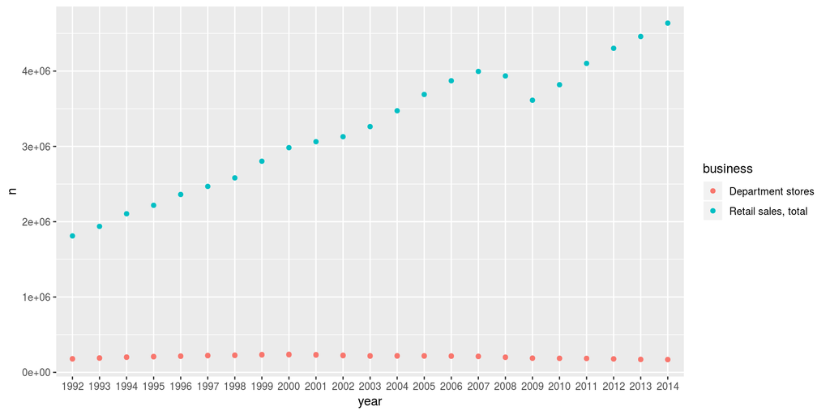

```r
## Plot Retail Sales data
ggplot(df_retail, aes(x=year,y=n,colour=business)) +
  geom_point()
```

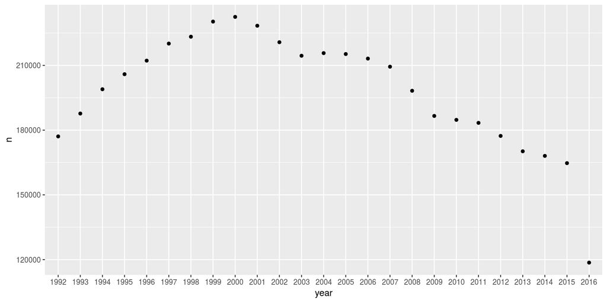

```r
## Plot Department Sales data
ggplot(df_department, aes(x=year,y=n)) +
  geom_point()
```

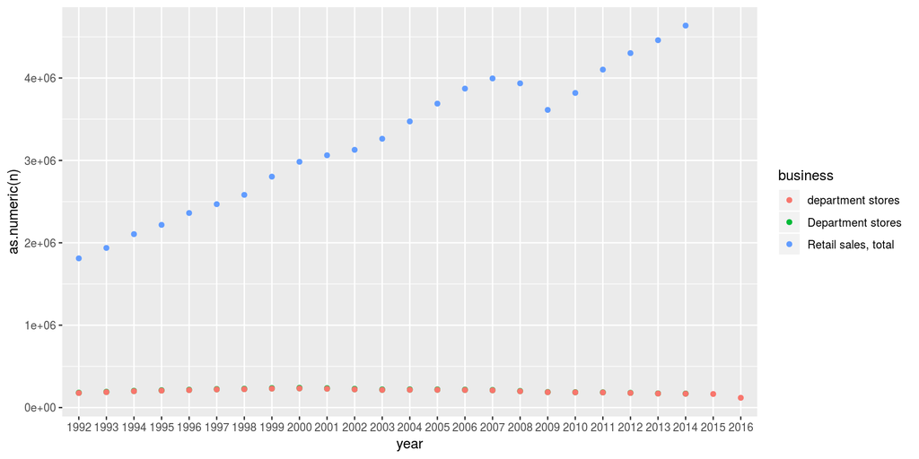

```r
## Plot Combined Data
ggplot(df_total, aes(x=year,y=as.numeric(n), colour=business)) +
  geom_point()
```